# Understanding Maternal Mortality in America

Malika Dosso

2024-10-21

Findings: US Maternal Mortality Analysis (2019-2024)

## 1. Overall Statistical Overview

- Complete Study Period Average: 22.97 deaths per 100,000 live births
- Range Analysis:
  - Absolute Minimum: 17.3 deaths per 100,000 live births (Pre-COVID)
  - Absolute Maximum: 33.8 deaths per 100,000 live births (February 2022)
  - Total Span: Initial rate 17.4 to final rate 19.6
- Volatility Measures:
  - Pre-COVID SD: 1.04
  - COVID Era SD: 4.67
  - Post-Dobbs SD: Variable (showing declining trend)

## 2. Pre-COVID Period (2019-March 2020)

Baseline Period Characteristics: * Duration: 14 months * Statistical Measures: - Mean Rate: 18.9 deaths per 100,000 live births - Standard Deviation: 1.04 (most stable period) - Range: 17.3-20.1 * Healthcare Metrics: - Average Monthly Deaths: 712 - Average Monthly Births: 3,761,836 * Trend Analysis: - Steady increase of 13.8% over period - Most consistent period with predictable patterns - Established baseline for comparison

## 3. COVID Era (March 2020-June 2022)

Peak Period Analysis: * Duration: 27 months * Critical Statistics: - Mean Rate: 26.4 deaths per 100,000 live births - Peak Rate: 33.8 (February 2022) - Standard Deviation: 4.67 (highest volatility) * Impact Metrics: - Total Increase: 57.7% - Average Monthly Deaths: 962 (250 more than pre-COVID) - Average Monthly Births: 3,648,065 (decline of 113,771) * Pattern Analysis: - Consistent upward trend - Highest volatility in rates - Significant monthly variations

## 4. Post-Dobbs Period (June 2022-Present)

Transition and Recovery Phase: * Duration: 25 months * Key Metrics: - Mean Rate: 21.6 deaths per 100,000 live births - Initial Rate: 32.1 - Final Rate: 19.6 - Total Decline: 38.9% * Volume Statistics: - Average Monthly Deaths: 786 - Average Monthly Births: 3,639,959 * Trend Analysis: - Consistent downward trend - Moving toward pre-COVID levels - Stabilizing patterns emerging

## 5. Racial Disparity Analysis

Detailed Breakdown by Race/Ethnicity:

American Indian/Alaska Native: * Highest Overall Rates: - COVID Era Mean: 98.2 - Post-Dobbs Mean: 86.5 - Disparity Ratio: 3.90x higher than White rate

Black, Non-Hispanic: * Consistently Second Highest: - COVID Era Mean: 59.0 - Post-Dobbs Mean: 51.3 - Disparity Ratio: 2.78x higher than White rate

White, Non-Hispanic (Reference Group): * Baseline Metrics: - COVID Era Mean: 21.4 - Post-Dobbs Mean: 17.6 - Used as reference for disparity calculations

Hispanic: * Variable Patterns: - COVID Era Mean: 21.0 - Post-Dobbs Mean: 15.9 - Disparity Ratio: 0.973x (near parity with White rate)

## 6. Annual Progression Analysis

Yearly Rate Changes: * 2019: 18.8 (Baseline Year) - Stable patterns - Pre-pandemic normal * 2020: 21.4 - Increase: 14.2% - Initial COVID impact * 2021: 27.5 - Increase: 28.1% - Peak COVID impact * 2022: 29.5 - Increase: 7.34% - Transition year (COVID/Dobbs) * 2023: 19.7 - Decrease: 33.3% - Major recovery period * 2024: 19.0 - Decrease: 3.09% - Continuing stabilization

## 7. Birth Rate Trends

Longitudinal Birth Analysis: * Pre-COVID Average: 3,761,836 - Highest birth rates - Stable patterns * COVID Era Average: 3,648,065 - Decline of 113,771 births - Consistent decrease * Post-Dobbs Average: 3,639,959 - Further slight decline - Minimal change from COVID era

```r
library(tidyverse)
library(lubridate)
```

```r
VSRR_MM <- read.csv("~/Downloads/VSRR_Provisional_Maternal_Death_Counts_and_Rates.csv")
```

```r
head(VSRR_MM)
```

```
  Data.As.Of  Jurisdiction Group Subgroup Year.of.Death Month.of.Death
1 10/06/2024 United States Total    Total          2019              1
2 10/06/2024 United States Total    Total          2019              2
3 10/06/2024 United States Total    Total          2019              3
4 10/06/2024 United States Total    Total          2019              4
5 10/06/2024 United States Total    Total          2019              5
6 10/06/2024 United States Total    Total          2019              6
      Time.Period Month.Ending.Date Maternal.Deaths Live.Births
1 12 month-ending        01/31/2019             660   3,787,776
2 12 month-ending        02/28/2019             653   3,783,489
3 12 month-ending        03/31/2019             657   3,771,682
4 12 month-ending        04/30/2019             668   3,772,235
5 12 month-ending        05/31/2019             706   3,767,999
6 12 month-ending        06/30/2019             720   3,757,275
  Maternal.Mortality.Rate Footnote
1                    17.4
2                    17.3
3                    17.4
4                    17.7
5                    18.7
6                    19.2
```

```r
str(VSRR_MM)
```

```
'data.frame':   660 obs. of  12 variables:
 $ Data.As.Of             : chr  "10/06/2024" "10/06/2024" "10/06/2024" "10/06/2024" ...
 $ Jurisdiction           : chr  "United States" "United States" "United States" "United States" ...
 $ Group                  : chr  "Total" "Total" "Total" "Total" ...
 $ Subgroup               : chr  "Total" "Total" "Total" "Total" ...
 $ Year.of.Death          : int  2019 2019 2019 2019 2019 2019 2019 2019 2019 2019 ...
 $ Month.of.Death         : int  1 2 3 4 5 6 7 8 9 10 ...
 $ Time.Period            : chr  "12 month-ending" "12 month-ending" "12 month-ending" "12 month-ending" ...
 $ Month.Ending.Date      : chr  "01/31/2019" "02/28/2019" "03/31/2019" "04/30/2019" ...
 $ Maternal.Deaths        : chr  "660" "653" "657" "668" ...
 $ Live.Births            : chr  "3,787,776" "3,783,489" "3,771,682" "3,772,235" ...
 $ Maternal.Mortality.Rate: num  17.4 17.3 17.4 17.7 18.7 19.2 19.2 19.2 19.4 19.7 ...
 $ Footnote               : chr  "" "" "" "" ...
```

```r
summary(VSRR_MM)
```

```
  Data.As.Of        Jurisdiction          Group             Subgroup
 Length:660         Length:660         Length:660         Length:660
 Class :character   Class :character   Class :character   Class :character
 Mode  :character   Mode  :character   Mode  :character   Mode  :character




 Year.of.Death  Month.of.Death   Time.Period        Month.Ending.Date
 Min.   :2019   Min.   : 1.000   Length:660         Length:660
 1st Qu.:2020   1st Qu.: 3.000   Class :character   Class :character
 Median :2021   Median : 6.000   Mode  :character   Mode  :character
 Mean   :2021   Mean   : 6.227
 3rd Qu.:2023   3rd Qu.: 9.000
 Max.   :2024   Max.   :12.000

 Maternal.Deaths    Live.Births        Maternal.Mortality.Rate
 Length:660         Length:660         Min.   :  0.00
 Class :character   Class :character   1st Qu.: 14.90
 Mode  :character   Mode  :character   Median : 19.80
                                       Mean   : 33.28
                                       3rd Qu.: 42.67
                                       Max.   :141.90
                                       NA's   :116
   Footnote
 Length:660
 Class :character
 Mode  :character
```

```r
names(VSRR_MM)
```

```
 [1] "Data.As.Of"              "Jurisdiction"
 [3] "Group"                   "Subgroup"
 [5] "Year.of.Death"           "Month.of.Death"
 [7] "Time.Period"             "Month.Ending.Date"
 [9] "Maternal.Deaths"         "Live.Births"
[11] "Maternal.Mortality.Rate" "Footnote"
```

```r
colSums(is.na(VSRR_MM))
```

```
             Data.As.Of            Jurisdiction                   Group
                      0                       0                       0
               Subgroup           Year.of.Death          Month.of.Death
                      0                       0                       0
            Time.Period       Month.Ending.Date         Maternal.Deaths
                      0                       0                       0
            Live.Births Maternal.Mortality.Rate                Footnote
                      0                     116                       0
```

```r
# Cleaning and formatting the data
VSRR_MM_clean <- VSRR_MM %>%
  # Converting character numbers to numeric
  mutate(
    # Removing commas and converting to numeric
    Maternal.Deaths = as.numeric(gsub(",", "", Maternal.Deaths)),
    Live.Births = as.numeric(gsub(",", "", Live.Births)),
    # Creating proper date from Month.Ending.Date
    Date = mdy(Month.Ending.Date)
  ) %>%
  # Filter Total group and subgroup to avoid duplicates
  filter(Group == "Total" & Subgroup == "Total") %>%
  # Arranging by date
  arrange(Date)

head(VSRR_MM_clean)
```

```
  Data.As.Of  Jurisdiction Group Subgroup Year.of.Death Month.of.Death
1 10/06/2024 United States Total    Total          2019              1
2 10/06/2024 United States Total    Total          2019              2
3 10/06/2024 United States Total    Total          2019              3
4 10/06/2024 United States Total    Total          2019              4
5 10/06/2024 United States Total    Total          2019              5
6 10/06/2024 United States Total    Total          2019              6
      Time.Period Month.Ending.Date Maternal.Deaths Live.Births
1 12 month-ending        01/31/2019             660     3787776
2 12 month-ending        02/28/2019             653     3783489
3 12 month-ending        03/31/2019             657     3771682
4 12 month-ending        04/30/2019             668     3772235
5 12 month-ending        05/31/2019             706     3767999
6 12 month-ending        06/30/2019             720     3757275
  Maternal.Mortality.Rate Footnote       Date
1                    17.4          2019-01-31
2                    17.3          2019-02-28
3                    17.4          2019-03-31
4                    17.7          2019-04-30
5                    18.7          2019-05-31
6                    19.2          2019-06-30
```

```r
# Structure of cleaned data
str(VSRR_MM_clean)
```

```
'data.frame':   66 obs. of  13 variables:
 $ Data.As.Of             : chr  "10/06/2024" "10/06/2024" "10/06/2024" "10/06/2024" ...
 $ Jurisdiction           : chr  "United States" "United States" "United States" "United States" ...
 $ Group                  : chr  "Total" "Total" "Total" "Total" ...
 $ Subgroup               : chr  "Total" "Total" "Total" "Total" ...
 $ Year.of.Death          : int  2019 2019 2019 2019 2019 2019 2019 2019 2019 2019 ...
 $ Month.of.Death         : int  1 2 3 4 5 6 7 8 9 10 ...
 $ Time.Period            : chr  "12 month-ending" "12 month-ending" "12 month-ending" "12 month-ending" ...
 $ Month.Ending.Date      : chr  "01/31/2019" "02/28/2019" "03/31/2019" "04/30/2019" ...
 $ Maternal.Deaths        : num  660 653 657 668 706 720 721 723 729 739 ...
 $ Live.Births            : num  3787776 3783489 3771682 3772235 3767999 ...
 $ Maternal.Mortality.Rate: num  17.4 17.3 17.4 17.7 18.7 19.2 19.2 19.2 19.4 19.7 ...
 $ Footnote               : chr  "" "" "" "" ...
 $ Date                   : Date, format: "2019-01-31" "2019-02-28" ...
```

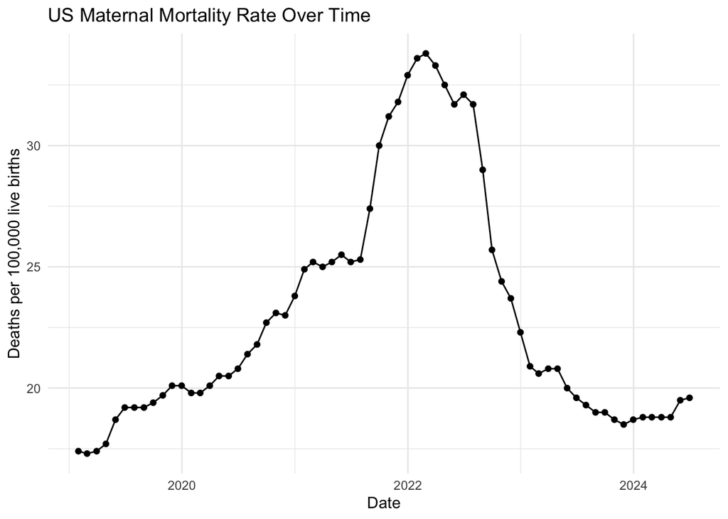

```r
# Trend plot to verify data
ggplot(VSRR_MM_clean, aes(x = Date, y = Maternal.Mortality.Rate)) +
  geom_line() + geom_point() + theme_minimal() +
  labs(title = "US Maternal Mortality Rate Over Time", x = "Date",
       y = "Deaths per 100,000 live births")
```

```r
# Calculating basic statistics
summary_stats <- VSRR_MM_clean %>%
  summarise( avg_rate = mean(Maternal.Mortality.Rate, na.rm = TRUE),
             min_rate = min(Maternal.Mortality.Rate, na.rm = TRUE),
             max_rate = max(Maternal.Mortality.Rate, na.rm = TRUE),
             start_rate = first(Maternal.Mortality.Rate),
             end_rate = last(Maternal.Mortality.Rate))

summary_stats
```

```
  avg_rate min_rate max_rate start_rate end_rate
1 22.97424     17.3     33.8       17.4     19.6
```

```r
# Time period labels
VSRR_MM_analysis <- VSRR_MM_clean %>%
  mutate(
    period = case_when(
      Date < as.Date("2020-03-01") ~ "Pre-COVID",
      Date >= as.Date("2020-03-01") & Date < as.Date("2022-06-24") ~ "COVID Era",
      Date >= as.Date("2022-06-24") ~ "Post-Dobbs",
      TRUE ~ "Other"
    )
  )

head(VSRR_MM_analysis)
```

```
  Data.As.Of  Jurisdiction Group Subgroup Year.of.Death Month.of.Death
1 10/06/2024 United States Total    Total          2019              1
2 10/06/2024 United States Total    Total          2019              2
3 10/06/2024 United States Total    Total          2019              3
4 10/06/2024 United States Total    Total          2019              4
5 10/06/2024 United States Total    Total          2019              5
6 10/06/2024 United States Total    Total          2019              6
      Time.Period Month.Ending.Date Maternal.Deaths Live.Births
1 12 month-ending        01/31/2019             660     3787776
2 12 month-ending        02/28/2019             653     3783489
3 12 month-ending        03/31/2019             657     3771682
4 12 month-ending        04/30/2019             668     3772235
5 12 month-ending        05/31/2019             706     3767999
6 12 month-ending        06/30/2019             720     3757275
  Maternal.Mortality.Rate Footnote       Date    period
1                    17.4          2019-01-31 Pre-COVID
2                    17.3          2019-02-28 Pre-COVID
3                    17.4          2019-03-31 Pre-COVID
4                    17.7          2019-04-30 Pre-COVID
5                    18.7          2019-05-31 Pre-COVID
6                    19.2          2019-06-30 Pre-COVID
```

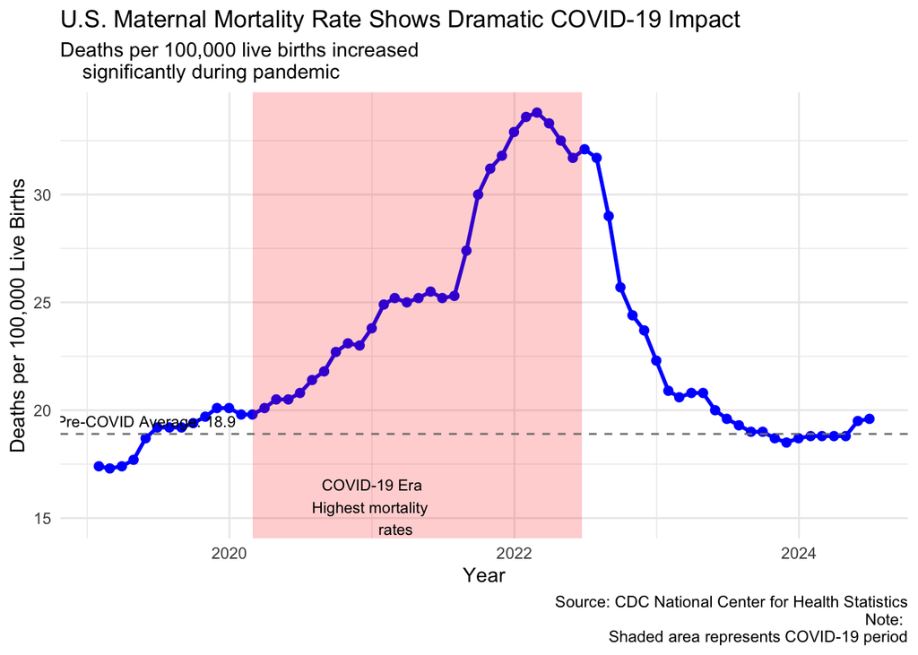

```r
# Trend plot with periods
ggplot(VSRR_MM_analysis, aes(x = Date, y = Maternal.Mortality.Rate)) +
  geom_line(size = 1, color = "blue") +
  geom_point(size = 2, color = "blue") +
  # Period shading
  annotate("rect",
           xmin = as.Date("2020-03-01"),
           xmax = as.Date("2022-06-24"),
           ymin = -Inf, ymax = Inf,
           alpha = 0.2, fill = "red") +
  annotate("text", x = as.Date("2021-01-01"), y = 15,
           label = "COVID-19 Era\nHighest mortality
           rates\nPeak: 33.8 deaths per 100,000",
           size = 3) +
  # Trend highlights
  geom_hline(yintercept = 18.9, linetype = "dashed", color = "gray50") +
  annotate("text", x = as.Date("2019-06-01"), y = 19.5,
           label = "Pre-COVID Average: 18.9", size = 3) +
  theme_minimal() +
  labs(
    title = "U.S. Maternal Mortality Rate Shows Dramatic COVID-19 Impact",
    subtitle = "Deaths per 100,000 live births increased
    significantly during pandemic",
    x = "Year",
    y = "Deaths per 100,000 Live Births",
    caption = "Source: CDC National Center for Health Statistics\nNote:
    Shaded area represents COVID-19 period"
  )
```

```r
# Statistics by period
period_stats <- VSRR_MM_analysis %>% group_by(period) %>%
  summarise(avg_rate = mean(Maternal.Mortality.Rate, na.rm = TRUE),
            min_rate = min(Maternal.Mortality.Rate, na.rm = TRUE),
            max_rate = max(Maternal.Mortality.Rate, na.rm = TRUE),
            num_months = n()) %>% arrange(min_rate)

# Percent changes between periods
changes <- VSRR_MM_analysis %>% group_by(period) %>%
  summarise(start_rate = first(Maternal.Mortality.Rate),
            end_rate = last(Maternal.Mortality.Rate),
            total_change = end_rate - start_rate,
            percent_change = ((end_rate - start_rate) / start_rate) * 100)


# Statistics by Period
period_stats
```

```
# A tibble: 3 × 5
  period     avg_rate min_rate max_rate num_months
  <chr>         <dbl>    <dbl>    <dbl>      <int>
1 Pre-COVID      18.9     17.3     20.1         14
2 Post-Dobbs     21.6     18.5     32.1         25
3 COVID Era      26.4     20.1     33.8         27
```

```r
# Changes within Each Period
changes
```

```
# A tibble: 3 × 5
  period     start_rate end_rate total_change percent_change
  <chr>           <dbl>    <dbl>        <dbl>          <dbl>
1 COVID Era        20.1     31.7        11.6            57.7
2 Post-Dobbs       32.1     19.6       -12.5           -38.9
3 Pre-COVID        17.4     19.8         2.40           13.8
```

```r
# Peak analysis
peak_analysis <- VSRR_MM_analysis %>%
  filter(Maternal.Mortality.Rate == max(Maternal.Mortality.Rate)) %>%
  select(Date, Maternal.Mortality.Rate, period)

#Peak Mortality Rate
peak_analysis
```

```
        Date Maternal.Mortality.Rate    period
1 2022-02-28                    33.8 COVID Era
```

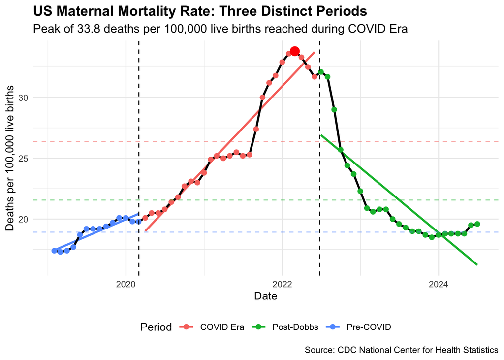

```r
# More detailed trend analysis
ggplot(VSRR_MM_analysis, aes(x = Date, y = Maternal.Mortality.Rate)) +
  # Trend lines for each period
  geom_smooth(aes(color = period), method = "lm", se = FALSE) +
  geom_line(size = 1) + geom_point(aes(color = period), size = 2) +
  # Period-specific average lines
  geom_hline(data = period_stats,
             aes(yintercept = avg_rate, color = period),
             linetype = "dashed", alpha = 0.5) +
  # Peak point Highlighted
  geom_point(data = peak_analysis,
             aes(x = Date, y = Maternal.Mortality.Rate),
             color = "red", size = 4) +

  # Vertical lines for key events
  geom_vline(xintercept = as.Date("2020-03-01"),
             linetype = "dashed", color = "gray4") +
  geom_vline(xintercept = as.Date("2022-06-24"),
             linetype = "dashed", color = "gray4") + theme_minimal() +
  theme(legend.position = "bottom",
        plot.title = element_text(size = 14, face = "bold"),
        plot.subtitle = element_text(size = 12),
        axis.title = element_text(size = 11)) +
  labs(title = "US Maternal Mortality Rate: Three Distinct Periods",
    subtitle = paste("Peak of",
                     round(max
                           (VSRR_MM_analysis$Maternal.Mortality.Rate, na.rm =
                               TRUE), 1),
                    "deaths per 100,000 live births reached during COVID Era"),
    x = "Date", y = "Deaths per 100,000 live births", color = "Period",
    caption = "Source: CDC National Center for Health Statistics")
```

```r
# Yearly averages and changes
yearly_stats <- VSRR_MM_analysis %>% mutate(year = year(Date)) %>%
  group_by(year) %>% summarise(avg_rate = mean(Maternal.Mortality.Rate,
                                               na.rm = TRUE),
                               min_rate = min(Maternal.Mortality.Rate,
                                              na.rm = TRUE),
    max_rate = max(Maternal.Mortality.Rate, na.rm = TRUE)
  ) %>% mutate(year_over_year_change = avg_rate - lag(avg_rate),
               percent_change = (avg_rate - lag(avg_rate))/lag(avg_rate) * 100)

yearly_stats
```

```
# A tibble: 6 × 6
   year avg_rate min_rate max_rate year_over_year_change percent_change
  <dbl>    <dbl>    <dbl>    <dbl>                 <dbl>          <dbl>
1  2019     18.8     17.3     20.1                NA              NA
2  2020     21.4     19.8     23.8                 2.66           14.2
3  2021     27.5     24.9     32.9                 6.02           28.1
4  2022     29.5     22.3     33.8                 2.02            7.34
5  2023     19.7     18.5     20.9                -9.82          -33.3
6  2024     19.0     18.8     19.6                -0.608          -3.09
```

```r
# Key statistics for each period
period_analysis <- VSRR_MM_analysis %>% group_by(period) %>%
  summarise(duration_months = n(),
            avg_deaths = mean(Maternal.Deaths, na.rm = TRUE),
            avg_births = mean(Live.Births, na.rm = TRUE),
            peak_rate = max(Maternal.Mortality.Rate, na.rm = TRUE),
            lowest_rate = min(Maternal.Mortality.Rate, na.rm = TRUE),
            rate_volatility = sd(Maternal.Mortality.Rate, na.rm = TRUE)) %>%
  mutate(deaths_per_month = avg_deaths/duration_months,
         births_per_month = avg_births/duration_months)

period_analysis
```

```
# A tibble: 3 × 9
  period     duration_months avg_deaths avg_births peak_rate lowest_rate
  <chr>                <int>      <dbl>      <dbl>     <dbl>       <dbl>
1 COVID Era               27       962.   3648065.      33.8        20.1
2 Post-Dobbs              25       786.   3639959       32.1        18.5
3 Pre-COVID               14       712.   3761836.      20.1        17.3
# ℹ 3 more variables: rate_volatility <dbl>, deaths_per_month <dbl>,
#   births_per_month <dbl>
```

```r
VSRR_MM_race <- VSRR_MM %>%
  # Filter for Race and Hispanic origin group
  filter(`Group` == "Race and Hispanic origin") %>%
  # Remove any rows with suppressed or missing data
  filter(!is.na(Maternal.Mortality.Rate)) %>%
  mutate(
    # Clean numeric columns
    Maternal.Deaths = as.numeric(gsub(",", "", Maternal.Deaths)),
    Live.Births = as.numeric(gsub(",", "", Live.Births)),
    Date = mdy(Month.Ending.Date),
    # Add period labels
    period = case_when(
      Date < as.Date("2020-03-01") ~ "Pre-COVID",
      Date >= as.Date("2020-03-01") & Date < as.Date("2022-06-24") ~ "COVID Era",
      Date >= as.Date("2022-06-24") ~ "Post-Dobbs",
      TRUE ~ "Other"
    )
  )

head(VSRR_MM_race)
```

```
  Data.As.Of  Jurisdiction                    Group Subgroup Year.of.Death
1 10/06/2024 United States Race and Hispanic origin Hispanic          2019
2 10/06/2024 United States Race and Hispanic origin Hispanic          2019
3 10/06/2024 United States Race and Hispanic origin Hispanic          2019
4 10/06/2024 United States Race and Hispanic origin Hispanic          2019
5 10/06/2024 United States Race and Hispanic origin Hispanic          2019
6 10/06/2024 United States Race and Hispanic origin Hispanic          2019
  Month.of.Death     Time.Period Month.Ending.Date Maternal.Deaths Live.Births
1              1 12 month-ending        01/31/2019              90      885705
2              2 12 month-ending        02/28/2019              90      885333
3              3 12 month-ending        03/31/2019              89      883687
4              4 12 month-ending        04/30/2019              96      884928
5              5 12 month-ending        05/31/2019             103      884930
6              6 12 month-ending        06/30/2019             105      883801
  Maternal.Mortality.Rate Footnote       Date    period
1                    10.2          2019-01-31 Pre-COVID
2                    10.2          2019-02-28 Pre-COVID
3                    10.1          2019-03-31 Pre-COVID
4                    10.8          2019-04-30 Pre-COVID
5                    11.6          2019-05-31 Pre-COVID
6                    11.9          2019-06-30 Pre-COVID
```

```r
# Statistics by period and race/ethnicity
racial_stats <- VSRR_MM_race %>%
  group_by(period, Subgroup) %>%
  summarise(
    mean_rate = mean(Maternal.Mortality.Rate, na.rm = TRUE),
    median_rate = median(Maternal.Mortality.Rate, na.rm = TRUE),
    min_rate = min(Maternal.Mortality.Rate, na.rm = TRUE),
    max_rate = max(Maternal.Mortality.Rate, na.rm = TRUE),
    sd_rate = sd(Maternal.Mortality.Rate, na.rm = TRUE),
    .groups = "drop"
  ) %>%
  arrange(period, desc(mean_rate))

# Disparities using reframe
disparity_calc <- VSRR_MM_race %>%
  group_by(Date, period) %>%
  reframe(
    Subgroup = Subgroup,
    Mortality_Rate = Maternal.Mortality.Rate,
    White_Rate = Maternal.Mortality.Rate[Subgroup == "White, Non-Hispanic"],
    Relative_Disparity = Maternal.Mortality.Rate /
      Maternal.Mortality.Rate[Subgroup == "White, Non-Hispanic"]
  ) %>%
  filter(Subgroup != "White, Non-Hispanic") # Remove reference group

head(racial_stats)
```

```
# A tibble: 6 × 7
  period     Subgroup            mean_rate median_rate min_rate max_rate sd_rate
  <chr>      <chr>                   <dbl>       <dbl>    <dbl>    <dbl>   <dbl>
1 COVID Era  American Indian or…      98.2        95.9     80.2    119.    10.3
2 COVID Era  Black, Non-Hispanic      59.0        57.5     44.4     72.7    8.89
3 COVID Era  White, Non-Hispanic      21.4        19.7     17.2     28      3.76
4 COVID Era  Hispanic                 21.0        21       12.9     28.5    5.09
5 COVID Era  Asian, Non-Hispanic      14.2        13.3     10.6     19.8    2.82
6 Post-Dobbs American Indian or…      86.5        89.1     77.6     92.8    7.93
```

```r
head(disparity_calc)
```

```
# A tibble: 6 × 6
  Date       period    Subgroup     Mortality_Rate White_Rate Relative_Disparity
  <date>     <chr>     <chr>                 <dbl>      <dbl>              <dbl>
1 2019-01-31 Pre-COVID Hispanic               10.2       14.9              0.685
2 2019-01-31 Pre-COVID Asian, Non-…           13.8       14.9              0.926
3 2019-01-31 Pre-COVID Black, Non-…           40.1       14.9              2.69
4 2019-02-28 Pre-COVID Hispanic               10.2       14.7              0.694
5 2019-02-28 Pre-COVID Asian, Non-…           12.5       14.7              0.850
6 2019-02-28 Pre-COVID Black, Non-…           40.1       14.7              2.73
```

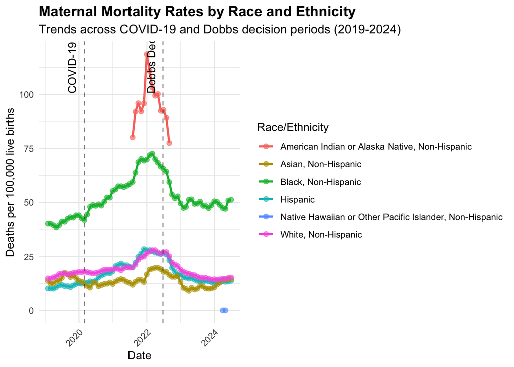

```r
ggplot(VSRR_MM_race, aes(x = Date, y = Maternal.Mortality.Rate,
color = Subgroup)) + geom_line(linewidth = 1) +
geom_point(size = 2, alpha = 0.6) +
geom_vline(xintercept = as.Date("2020-03-01"),
linetype = "dashed", color = "gray4", alpha = 0.5) +
geom_vline(xintercept = as.Date("2022-06-24"),
linetype = "dashed", color = "gray4", alpha = 0.5) +
annotate("text", x = as.Date("2020-01-15"),
y = max(VSRR_MM_race$Maternal.Mortality.Rate, na.rm = TRUE),
label = "COVID-19 Start", angle = 90, vjust = -0.5) +
annotate("text", x = as.Date("2022-05-15"),
y = max(VSRR_MM_race$Maternal.Mortality.Rate, na.rm = TRUE),
label = "Dobbs Decision", angle = 90, vjust = -0.5) +
theme_minimal() + theme(legend.position = "right", plot.title =
element_text(size = 14, face = "bold"),
plot.subtitle = element_text(size = 12),
axis.text.x = element_text(angle = 45, hjust = 1)) +
labs(
title = "Maternal Mortality Rates by Race and Ethnicity",
subtitle = "Trends across COVID-19 and Dobbs decision periods (2019-2024)",
x = "Date",
y = "Deaths per 100,000 live births",
color = "Race/Ethnicity"
)
```

```r
# Statistics by period and race/ethnicity
disparity_summary <- disparity_calc %>%
  group_by(period, Subgroup) %>%
  summarise(
    mean_disparity = mean(Relative_Disparity, na.rm = TRUE),
    median_disparity = median(Relative_Disparity, na.rm = TRUE),
    min_disparity = min(Relative_Disparity, na.rm = TRUE),
    max_disparity = max(Relative_Disparity, na.rm = TRUE),
    .groups = "drop"
  ) %>%
  arrange(period, desc(mean_disparity))

head(disparity_summary)
```

```
# A tibble: 6 × 6
  period    Subgroup mean_disparity median_disparity min_disparity max_disparity
  <chr>     <chr>             <dbl>            <dbl>         <dbl>         <dbl>
1 COVID Era America…          3.90             3.83          3.5           4.46
2 COVID Era Black, …          2.78             2.78          2.49          3.07
3 COVID Era Hispanic          0.973            0.992         0.725         1.17
4 COVID Era Asian, …          0.666            0.656         0.528         0.781
5 Post-Dob… America…          3.26             3.29          3.08          3.42
6 Post-Dob… Black, …          2.99             3.15          2.36          3.51
```

```r
# Period comparison with proper grouping
period_comparison <- racial_stats %>%
  select(period, Subgroup, mean_rate, max_rate) %>%
  pivot_wider(
    id_cols = Subgroup,
    names_from = period,
    values_from = c(mean_rate, max_rate)
  )

head(period_comparison)
```

```
# A tibble: 6 × 7
  Subgroup    `mean_rate_COVID Era` `mean_rate_Post-Dobbs` `mean_rate_Pre-COVID`
  <chr>                       <dbl>                  <dbl>                 <dbl>
1 American I…                  98.2                   86.5                  NA
2 Black, Non…                  59.0                   51.3                  41.4
3 White, Non…                  21.4                   17.6                  16.7
4 Hispanic                     21.0                   15.9                  11.4
5 Asian, Non…                  14.2                   12.8                  14.5
6 Native Haw…                  NA                      0                    NA
# ℹ 3 more variables: `max_rate_COVID Era` <dbl>, `max_rate_Post-Dobbs` <dbl>,
#   `max_rate_Pre-COVID` <dbl>
```